# Exploratory Data Analysis

Adapted for [ForestGEO](https://twitter.com/ForestGEO?lang=en) from [R for Data Science](http://r4ds.had.co.nz/), by [Hadley Wickham](https://twitter.com/hadleywickham) and [Garrett Grolemund](https://twitter.com/StatGarrett)

Mauro Lepore

2019-02-07

Here, I reproduce the section *Exploratory Data Analysis* of the book *R for Data Science* (http://r4ds.had.co.nz/), by Hadley Wickham and Garrett Grolemund – except for the examples and some text, which I changed to engage ecologists from ForestGEO.

# Introduction

This article will show you how to explore your data with general purpose tools, mostly from the **tidyverse** (https://www.tidyverse.org/). This is a good place to start before you learn the specific tools from the **fgeo** package (https://forestgeo.github.io/fgeo/). For an exploratory data analysis with **fgeo**, see [Get Started](https://forestgeo.github.io/fgeo/articles/fgeo.html#get-started).

You will learn to explore your data systematically by using modern and powerful tools for visualization and transformation. An exploratory data analysis is an iterative process that aims to use data and some research questions to learn something that can help you refine those questions and move forward along the learning spiral.

If you are new to the **tidyverse**, you may feel a little frustrated at the beginning, but your effort will quickly pay-off. The tools in the **tidyverse** are powerful, relatively easy to use, and consistent; so once you learn some of the tools, you will learn most other tools intuitively.

```r
library(tidyverse)
```

We will use the dataset `luquillo_stem_random` from the **fgeo.data** package (https://forestgeo.github.io/fgeo.data/), which records trees censused in a forest plot in Luquillo, Puerto Rico.

```r
# Convenient nickname
stem <- fgeo.x::download_data("luquillo_stem_random")
```

## Style

### The tidyverse style guide

The code style I use here follows the tidyverse guide (http://style.tidyverse.org/).

> Good coding style is like correct punctuation: you can manage without it, butitsuremakesthingseasiertoread.

### Combining multiple operations with the pipe %>%

Often I combine multiple operations with the pipe `%>%`, because it makes the code considerably more readable.

> [The pipe] focuses on the transformations, not what’s being transformed, which makes the code easier to read. You can read it as a series of imperative statements: group, then summarise, then filter. As suggested by this reading, a good way to pronounce %>% when reading code is “then”.

> Behind the scenes, `x %>% f(y)` turns into `f(x, y)`, and `x %>% f(y) %>% g(z)` turns into `g(f(x, y), z)` and so on. You can use the pipe to rewrite multiple operations in a way that you can read left-to-right, top-to-bottom.

> Working with the pipe is one of the key criteria for belonging to the tidyverse. The only exception is ggplot2: it was written before the pipe was discovered.

–- R for Data Science (http://r4ds.had.co.nz/transform.html)

# Questions and definitions

## Questions

To start exploring your data, you can generally ask these questions:

- What type of variation occurs within my variables?
- What type of covariation occurs between my variables?

## Definitions

A **variable** is a quantity, quality, or property that you can measure.

A **value** is the state of a variable when you measure it. The value of a variable may change from measurement to measurement.

An **observation** is a set of measurements made under similar conditions (you usually make all of the measurements in an observation at the same time and on the same object). An observation will contain several values, each associated with a different variable. I will sometimes refer to an observation as a data point.

**Tabular data** is a set of values, each associated with a variable and an observation. Tabular data is tidy if each value is placed in its own “cell”, each variable in its own column, and each observation in its own row.

**Variation** is the tendency of the values of a variable to change from measurement to measurement.

# Variation

Every variable varies with a particular pattern, and that pattern may be insightful. To understand the variation pattern of a variable, we can visualize the distribution of the variables’ values. The best way to visualize a variable’s distribution depends on whether the variable is categorical or continuous.

The `stem` dataset has both categorical and continuous variables. In R, categorical variables are usually stored as character strings (`<chr>`) or factors (`<fctr>`), and continuous variables are stored as integers (`<int>`) or doubles (`<dbl>`).

`stem` is a tibble. A tibble is a subclass of dataframe. But compared to regular dataframes, tibbles are optimized to handle large data; they also print more information and show it in a nicer way.

```r
class(stem)
```

```
#> [1] "tbl_df"     "tbl"        "data.frame"
```

```r
stem
```

```
#> # A tibble: 7,920 x 19
#>    treeID stemID tag   StemTag sp    quadrat    gx    gy MeasureID CensusID
#>     <int>  <int> <chr> <chr>   <chr> <chr>   <dbl> <dbl>     <int>    <int>
#>  1    104    143 10009 10009   DACE~ 113      10.3  245.       143        1
#>  2    119    158 1001~ 100104  MYRS~ 1021    183.   410.       158        1
#>  3    180    222 1001~ 100095  CASA~ 921     165.   410.       222        1
#>  4    180    223 1001~ 100096  CASA~ 921     165.   410.       223        1
#>  5    180    224 1001~ 100171  CASA~ 921     165.   410.       224        1
#>  6    180    225 1001~ 100174  CASA~ 921     165.   410.       225        1
#>  7    602    736 1006~ 100649  GUAG~ 821     149.   414.       736        1
#>  8    631    775 10069 10069   PREM~ 213      38.3  245.       775        1
#>  9    647    793 1007~ 100708  SCHM~ 821     143.   411.       793        1
#> 10   1086   1339 10122 10122   DRYG~ 413      68.9  253.      1339        1
#> # ... with 7,910 more rows, and 9 more variables: dbh <dbl>, pom <chr>,
#> #   hom <dbl>, ExactDate <date>, DFstatus <chr>, codes <chr>,
#> #   countPOM <dbl>, status <chr>, date <dbl>
```

By default, tibbles print a few rows only; to print more rows use:

```r
print(<YOUR_TIBBLE>, n = <N_ROWS>, width = <N_COLUMNS>)
```

You can always convert a tibble into a regular dataframe.

```r
# This is ackward because it prints way more than you can fit on a screen
as.data.frame(stem)
```

For alternative views try:

```r
# informative and prints nice
str(stem)
```

```
#> Classes 'tbl_df', 'tbl' and 'data.frame':    7920 obs. of  19 variables:
#>  $ treeID   : int  104 119 180 180 180 180 602 631 647 1086 ...
#>  $ stemID   : int  143 158 222 223 224 225 736 775 793 1339 ...
#>  $ tag      : chr  "10009" "100104" "100171" "100171" ...
#>  $ StemTag  : chr  "10009" "100104" "100095" "100096" ...
#>  $ sp       : chr  "DACEXC" "MYRSPL" "CASARB" "CASARB" ...
#>  $ quadrat  : chr  "113" "1021" "921" "921" ...
#>  $ gx       : num  10.3 182.9 164.6 164.6 164.6 ...
#>  $ gy       : num  245 410 410 410 410 ...
#>  $ MeasureID: int  143 158 222 223 224 225 736 775 793 1339 ...
#>  $ CensusID : int  1 1 1 1 1 1 1 1 1 1 ...
#>  $ dbh      : num  115 16 17.2 11.7 80 19.4 24.1 100 146 165 ...
#>  $ pom      : chr  "1.2" "1.3" "1.3" "1.3" ...
#>  $ hom      : num  1.2 1.3 1.3 1.3 1.3 1.3 1.3 1.3 1.3 1.3 ...
#>  $ ExactDate: Date, format: "1991-06-11" "1993-07-28" ...
#>  $ DFstatus : chr  "alive" "alive" "alive" "alive" ...
#>  $ codes    : chr  "MAIN;A" "MAIN;A" "SPROUT;A" "SPROUT;A" ...
#>  $ countPOM : num  1 1 1 1 1 1 1 1 1 1 ...
#>  $ status   : chr  "A" "A" "A" "A" ...
#>  $ date     : num  11484 12262 12263 12263 12263 ...
```

```r
# like str() but shows as much data as possible
glimpse(stem)
```

```
#> Observations: 7,920
#> Variables: 19
#> $ treeID    <int> 104, 119, 180, 180, 180, 180, 602, 631, 647, 1086, 1...
#> $ stemID    <int> 143, 158, 222, 223, 224, 225, 736, 775, 793, 1339, 1...
#> $ tag       <chr> "10009", "100104", "100171", "100171", "100171", "10...
#> $ StemTag   <chr> "10009", "100104", "100095", "100096", "100171", "10...
#> $ sp        <chr> "DACEXC", "MYRSPL", "CASARB", "CASARB", "CASARB", "C...
#> $ quadrat   <chr> "113", "1021", "921", "921", "921", "921", "821", "2...
#> $ gx        <dbl> 10.31, 182.89, 164.61, 164.61, 164.61, 164.61, 148.9...
#> $ gy        <dbl> 245.36, 410.15, 409.50, 409.50, 409.50, 409.50, 414....
#> $ MeasureID <int> 143, 158, 222, 223, 224, 225, 736, 775, 793, 1339, 1...
#> $ CensusID  <int> 1, 1, 1, 1, 1, 1, 1, 1, 1, 1, 1, 1, 1, 1, 1, 1, 1, 1...
#> $ dbh       <dbl> 115.0, 16.0, 17.2, 11.7, 80.0, 19.4, 24.1, 100.0, 14...
#> $ pom       <chr> "1.2", "1.3", "1.3", "1.3", "1.3", "1.3", "1.3", "1....
#> $ hom       <dbl> 1.20, 1.30, 1.30, 1.30, 1.30, 1.30, 1.30, 1.30, 1.30...
#> $ ExactDate <date> 1991-06-11, 1993-07-28, 1993-07-29, 1993-07-29, 199...
#> $ DFstatus  <chr> "alive", "alive", "alive", "alive", "alive", "alive"...
#> $ codes     <chr> "MAIN;A", "MAIN;A", "SPROUT;A", "SPROUT;A", "MAIN;A"...
#> $ countPOM  <dbl> 1, 1, 1, 1, 1, 1, 1, 1, 1, 1, 1, 1, 1, 1, 1, 1, 1, 1...
#> $ status    <chr> "A", "A", "A", "A", "A", "A", "A", "A", "A", "A", "A...
#> $ date      <dbl> 11484, 12262, 12263, 12263, 12263, 12263, 12264, 114...
```

If you are in RStudio, your best option might be `View()`, which lets you search values and filter columns.

```r
View(stem)
```

[figure not shown]

## Visualizing distributions

### Categorical variables

A variable is categorical if it can only take one of a small set of values. To examine the distribution of a categorical variable, use a bar chart.

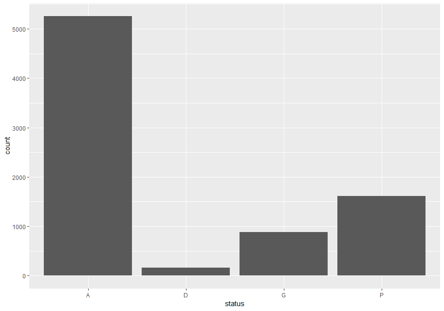

```r
ggplot(data = stem) +
  geom_bar(mapping = aes(x = status))
```

### Continuous variables

A variable is continuous if it can take any of an infinite set of ordered values. To examine the distribution of a continuous variable, use a histogram. You should always explore a variety of binwidths when working with histograms, as different binwidths can reveal different patterns.

Let’s explore `dbh`, which represents the stem diameter at breast height. Now we will focus on small stems; we will explore big stems later. And we will try bars of different widths (with `binwidth`) and choose one for further analyses.

```r
small_dbh <- filter(stem, dbh < 300)

# Save data and mappings in "p" to reuse them later.
p <- ggplot(small_dbh, aes(dbh))
```

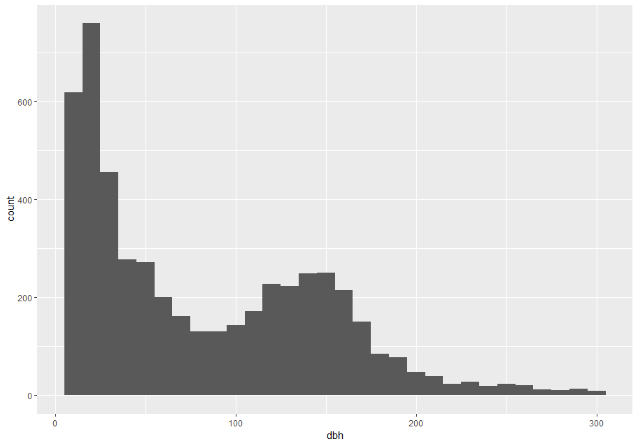

```r
p + geom_histogram(binwidth = 10)
```

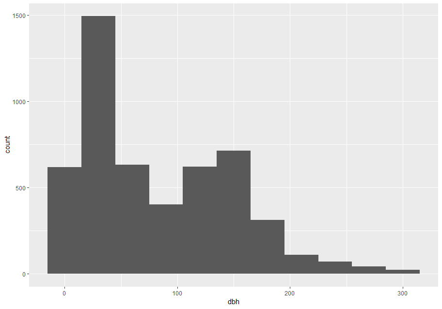

```r
p + geom_histogram(aes(dbh), binwidth = 30)
```

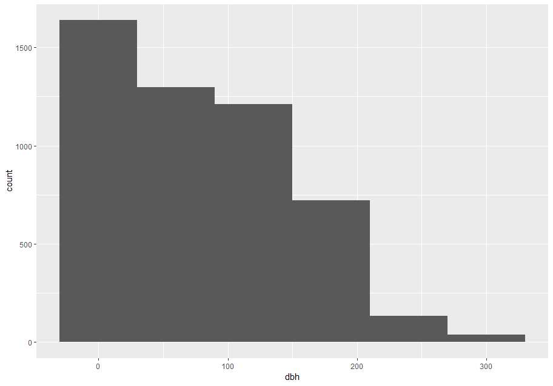

```r
p + geom_histogram(aes(dbh), binwidth = 60)
```

A binwidth of 30 seems useful.

```r
# Save to reuse
useful_binwidth <- 30
```

To overlay multiple histograms in the same plot, `geom_freqpoly()` may produce clearer plots than `geom_histogram()`, because it is easier to understand overlying lines than bars.

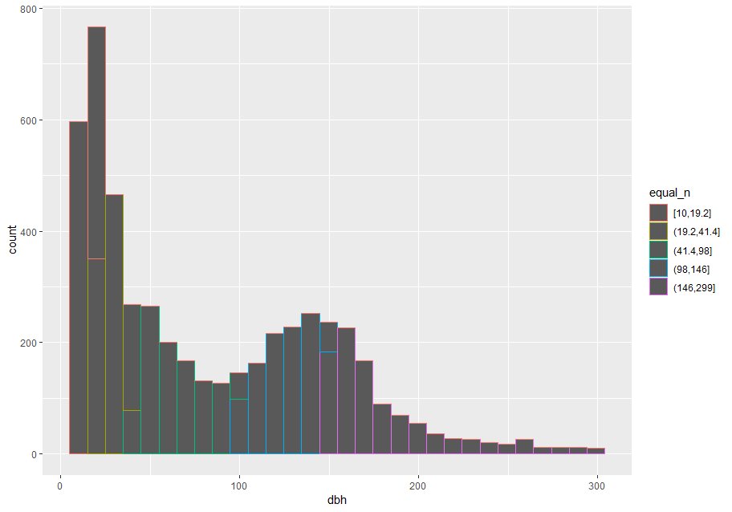

```r
# Make n groups with ~ numbers of observations with `ggplot2::cut_number()`
small_cut_number <- mutate(small_dbh, equal_n = cut_number(dbh, n = 5))

p <- ggplot(data = small_cut_number, aes(x = dbh, color = equal_n))

p + geom_histogram()
```

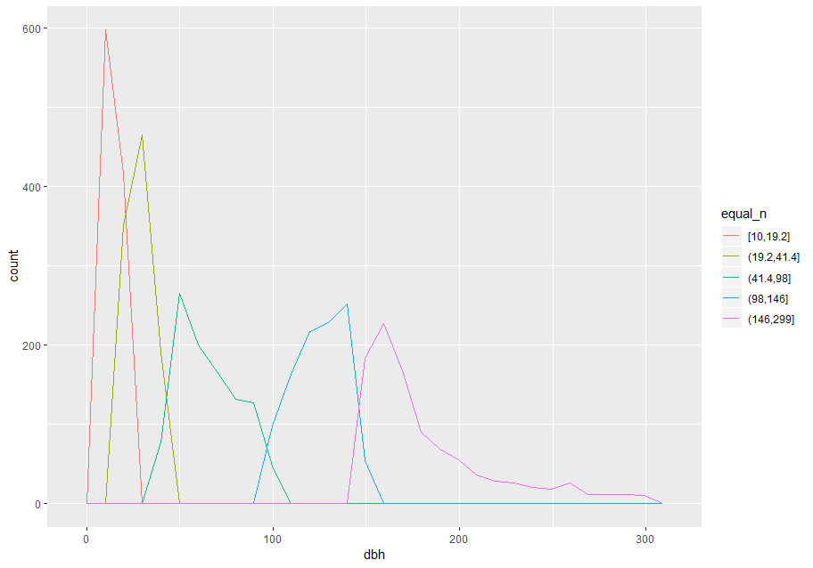

```r
p + geom_freqpoly()
```

### Typical and rare values

In both bar charts and histograms, tall and short bars let us explore common and less-common values. For example, we could ask:

- Which values are the most common? Why?
- Which values are rare? Why? Does that match your expectations?
- Can you see any unusual patterns? What might explain them?

The latter two plots give a good estimate of the most common stem-diameters. You can compute the same count manually by cutting the variable `dbh` with `ggplot2::cut_width()`, and then counting the unique pieces with `dplyr::count()`.

```r
small_dbh %>%
  mutate(dbh_mm = cut_width(dbh, width = useful_binwidth)) %>%
  count(dbh_mm, sort = TRUE)
```

```
#> # A tibble: 11 x 2
#>    dbh_mm        n
#>    <fct>     <int>
#>  1 (15,45]    1493
#>  2 (135,165]   714
#>  3 (45,75]     633
#>  4 (105,135]   622
#>  5 [-15,15]    619
#>  6 (75,105]    403
#>  7 (165,195]   312
#>  8 (195,225]   110
#>  9 (225,255]    70
#> 10 (255,285]    43
#> 11 (285,315]    23
```

The most common stems have a diameter at breast height (`dbh`) between 15 mm and 45 mm.

### Clustered values

In this section we will focus on the largest stems; later we will explore all stems.

```r
large_dbh <- stem %>% filter(dbh > 300)
```

Clusters of similar values suggest that subgroups exist in your data. To understand the subgroups, ask:

- How are the observations within each cluster similar to each other?
- How are the observations in separate clusters different from each other?
- How can you explain or describe the clusters?
- Why might the appearance of clusters be misleading?

The clustering, however, may be an artifact of the chosen binwidth:

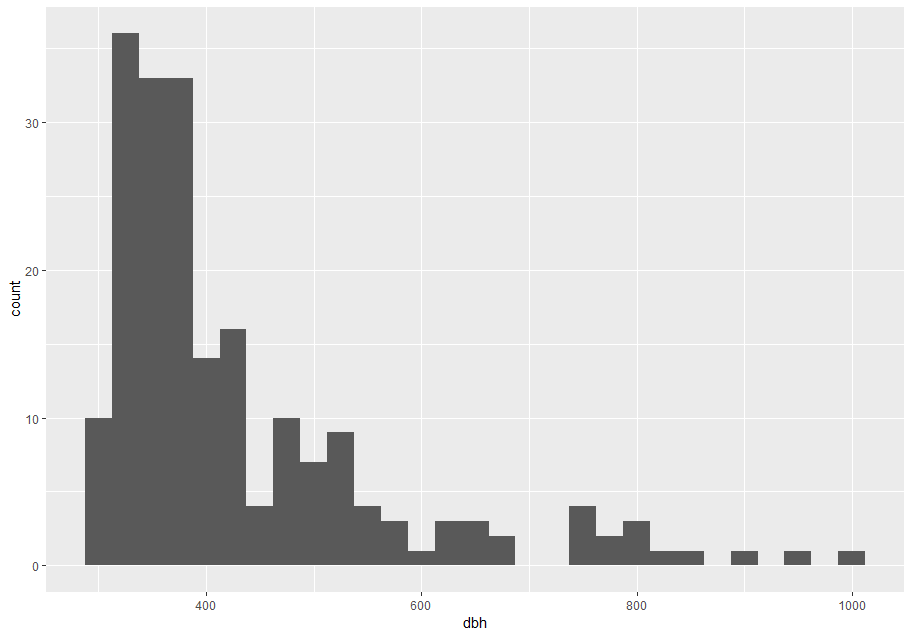

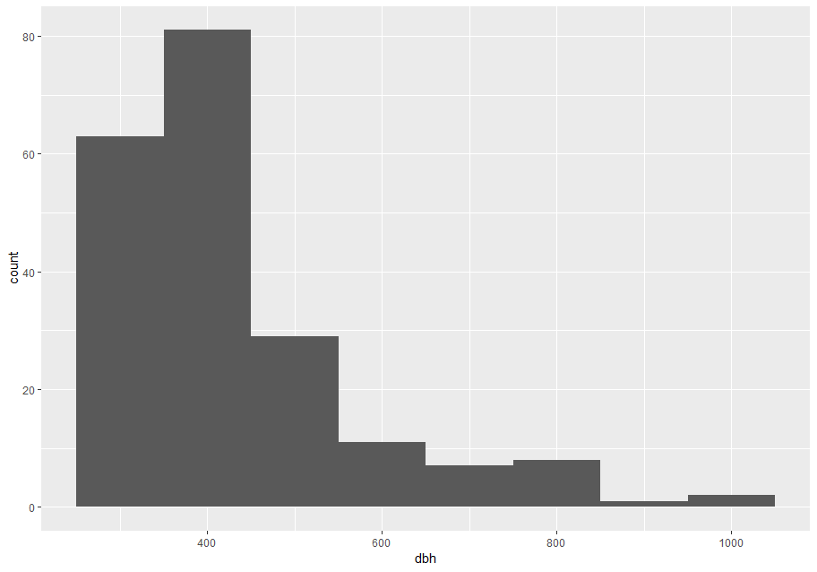

```r
p <- ggplot(large_dbh, aes(dbh))

# Left: Are these clusters meaningful?
p + geom_histogram(binwidth = 25)

# Right: Is this a more meaningful representation?
p + geom_histogram(binwidth = 100)
```

### Unusual values

In this section we will work with the entire `stem` dataset.

Outliers are observations that are unusual: data points that do not seem to fit the pattern. Sometimes outliers are data entry errors, while other times outliers suggest important new science. When you have a lot of data, outliers can be difficult to see in a histogram.

For example, consider the distribution of the `dbh` variable of the `stem` dataset. Notice how wide are the limits of the x-axis.

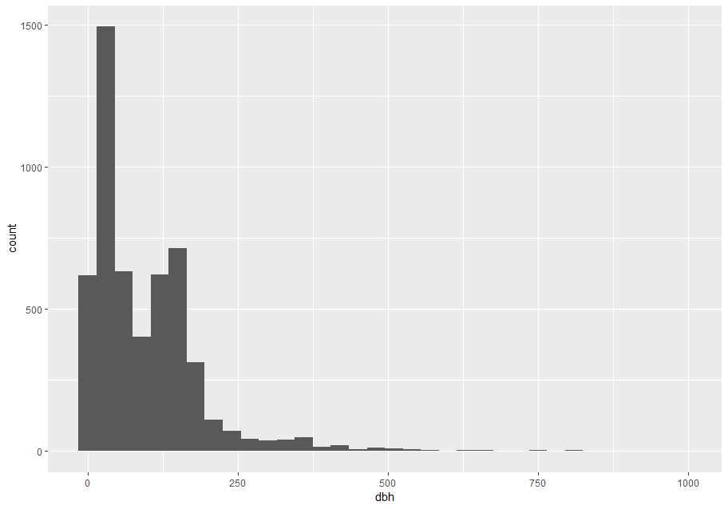

```r
p <- ggplot(stem, aes(dbh)) +
  geom_histogram(binwidth = useful_binwidth)
p
```

There are so many observations in the common bins that the rare bins are so short that you can barely see them. To make the unusual values more noticeable, we can zoom into smaller values of the y-axis with `coord_cartesian()`.

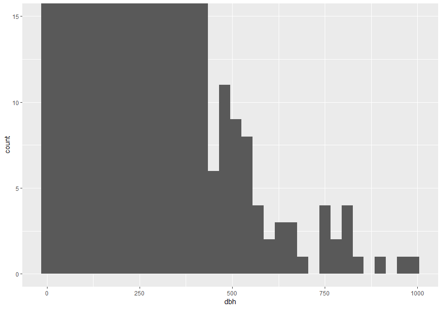

```r
p + coord_cartesian(ylim = c(0, 15))
```

`coord_cartesian()` also has an `xlim` argument for when you need to zoom into the x-axis. **ggplot2** also has `xlim()` and `ylim()` functions that work slightly differently: they throw away the data outside the limits.

This allows us to see that `dbh` values over ~625 are unusual and may be outliers. We can pluck them out with `dplyr::filter()` and select a subset of informative variables:

```r
treshold <- 625
unusual <- stem %>%
  filter(dbh > treshold ) %>%
  select(stemID, ExactDate, status, gx, gy, dbh) %>%
  arrange(dbh)
unusual
```

```
#> # A tibble: 19 x 6
#>    stemID ExactDate  status    gx    gy   dbh
#>     <int> <date>     <chr>  <dbl> <dbl> <dbl>
#>  1  80141 1991-04-03 A       138.  163.   642
#>  2  34692 2002-03-08 A       221.  445.   661
#>  3  34692 2012-03-06 A       221.  445.   661
#>  4  34692 2007-01-24 A       221.  445.   666
#>  5  34692 2016-09-06 A       221.  445.   676
#>  6  34692 1996-08-01 A       221.  445.   738
#>  7  30562 1996-03-15 A       118.  343.   740
#>  8  30562 2006-10-10 A       118.  343.   740
#>  9  30562 2001-09-27 A       118.  343.   751
#> 10  30562 2011-12-07 A       118.  343.   777
#> 11  30562 1991-09-13 A       118.  343.   787
#> 12  32585 1991-12-18 A       225.  397.   800
#> 13  32585 1996-06-06 A       225.  397.   809
#> 14  30562 2016-06-29 A       118.  343.   812
#> 15  34692 1992-01-11 A       221.  445.   823
#> 16  32585 2001-12-03 A       225.  397.   845
#> 17  32585 2006-11-06 A       225.  397.   903
#> 18  32585 2012-02-09 A       225.  397.   955
#> 19  32585 2016-08-04 A       225.  397.   992
```

You could plot the unusual stems to see where they are located.

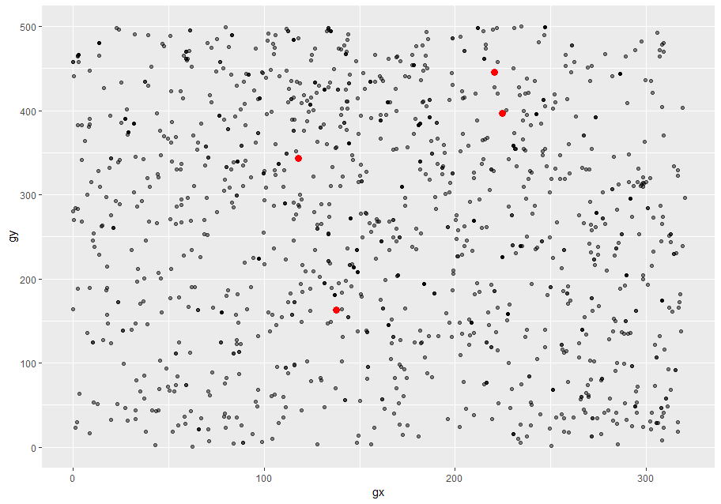

```r
ggplot(stem, aes(gx, gy)) +
    # `alpha` controls opacity
    geom_point(alpha = 1/10) +
    # highlight unusual stems
    geom_point(data = unusual, colour = "red", size = 3)
```

It is good practice to repeat your analysis with and without the outliers. If they have minimal effect on the results, and you can not figure out why they are there, it is reasonable to replace them with missing values, and move on. However, if they have a substantial effect on your results, you should not drop them without justification. You will need to figure out what caused them (e.g. a data entry error) and disclose that you removed them in your write-up.

# Missing values

If you have encountered unusual values in your dataset and simply want to move on to the rest of your analysis, you have two options.

1. Drop the entire row with the strange values:

```r
are_usual <- !stem$stemID %in% unusual$stemID
usual <- filter(stem, are_usual)

# Confirm dataset of usual stems has less rows than full dataset.
nrow(stem)
```

```
#> [1] 7920
```

```r
nrow(usual)
```

```
#> [1] 7896
```

I do not recommend this option: That one measurement is invalid does not mean all the measurements are invalid. Additionally, if you have low quality data, by the time you have applied this approach to every variable you might find that you are left with no data!

2. Instead, I recommend replacing the unusual values with missing values. The easiest way to do this is to use `dplyr::mutate()` to replace the variable with a modified copy. You can use the `ifelse()` function to replace unusual values with `NA`:

```r
are_unusual <- !are_usual
with_unusual_made_NA <- stem %>%
  mutate(dbh = ifelse(are_unusual, NA_real_, dbh))
```

`ifelse()` has three arguments. The first argument `test` should be a logical vector. The result will contain the value of the second argument, `yes`, when `test` is `TRUE`, and the value of the third argument, `no`, when it is `FALSE`.

```r
# Confirm no rows have been removed,
nrow(stem)
```

```
#> [1] 7920
```

```r
nrow(with_unusual_made_NA)
```

```
#> [1] 7920
```

```r
# but dbh of unusual stems is NA
unusual_only <- with_unusual_made_NA %>%
  filter(are_unusual) %>%
  select(dbh, stemID)
unusual_only
```

```
#> # A tibble: 24 x 2
#>      dbh stemID
#>    <dbl>  <int>
#>  1    NA  30562
#>  2    NA  32585
#>  3    NA  34692
#>  4    NA  80141
#>  5    NA  30562
#>  6    NA  32585
#>  7    NA  34692
#>  8    NA  80141
#>  9    NA  30562
#> 10    NA  32585
#> # ... with 14 more rows
```

Alternatively to `ifelse()`, use `dplyr::case_when()`. `case_when()` is particularly useful inside `mutate()` when you want to create a new variable that relies on a complex combination of existing variables.

It is not obvious where you should plot missing values in a plot, so **ggplot2** does not include them, but it does warn that they have been removed (left plot below). To suppress that warning, set `na.rm = TRUE` (right plot below).

```r
# Left: Keep NAs and get a warning on the console
ggplot(unusual_only, aes(dbh)) +
  geom_histogram(binwidth = useful_binwidth) +
  labs(title = "Expect empty plot but get a warning")
```

```
#> Warning: Removed 24 rows containing non-finite values (stat_bin).
```

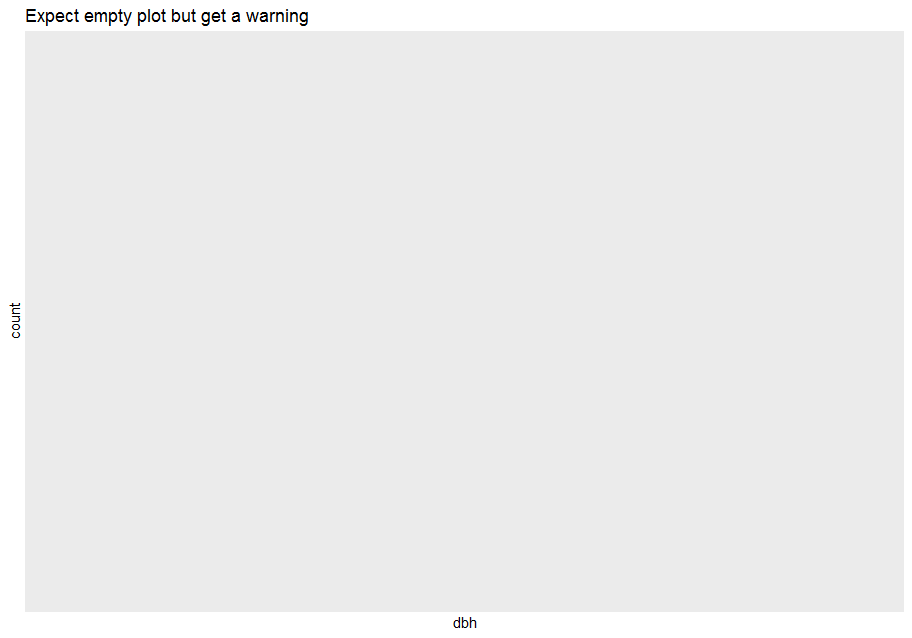

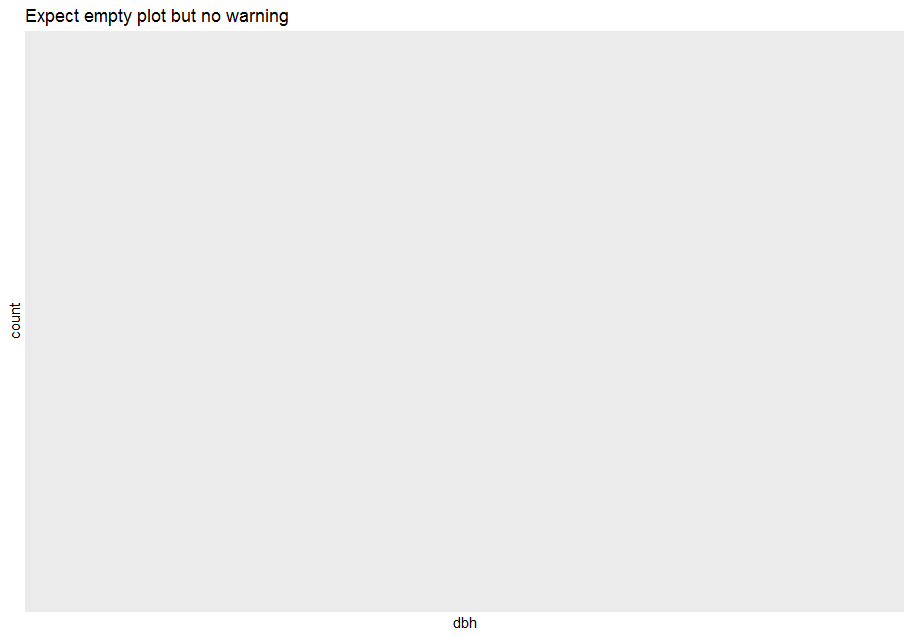

```r
# Right: Remove NAs explicitely in geom_histogram(), so no warning
ggplot(unusual_only, aes(dbh)) +
  geom_histogram(binwidth = useful_binwidth, na.rm = TRUE) +
  labs(title = "Expect empty plot but no warning")
```

Other times, you may want to understand what makes observations with missing values different to observations with recorded values.

For example, you might want to compare the `status` for stems with missing and non-missing values of `dbh`. You can do this by making a new variable with `is.na()`.

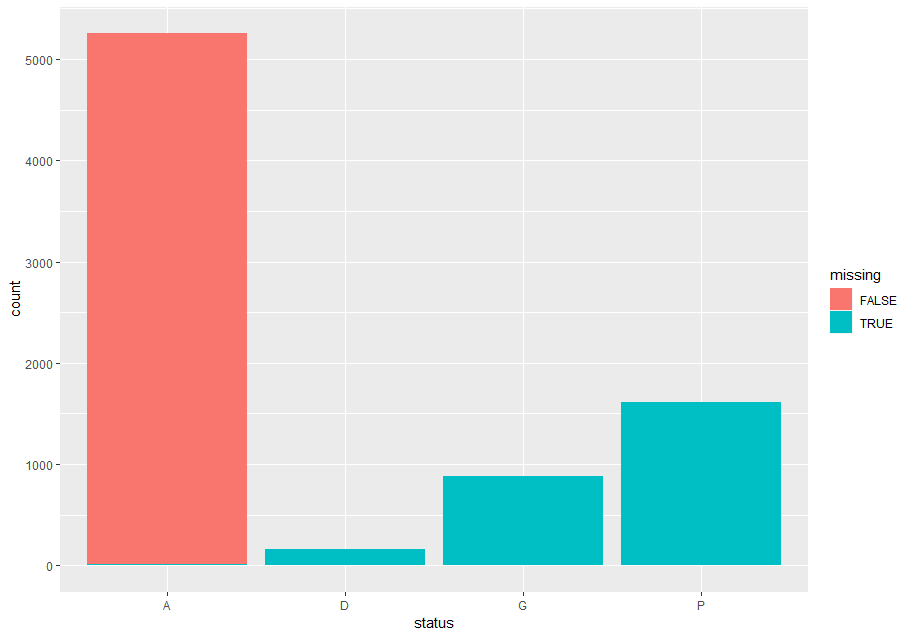

```r
missing_dbh <- stem %>%
  mutate(missing = is.na(dbh))

ggplot(missing_dbh) +
  geom_bar(aes(status, fill = missing))
```

## Exercises

1. What happens to missing values in a histogram? What happens to missing values in a bar chart? Why is there a difference?
2. What does `na.rm = TRUE` do in `mean()` and `sum()`?

# Covariation

If variation describes the behavior within a variable, covariation describes the behavior between variables. Covariation is the tendency for the values of two or more variables to vary together in a related way. The best way to spot covariation is to visualize the relationship between two or more variables. How you do that should again depend on the type of variables involved.

## A categorical and continuous variable

It is common to explore the distribution of a continuous variable broken down by a categorical variable. The default appearance of `geom_freqpoly()` is not that useful for that sort of comparison since the height is given by the count. That means if one of the groups is much smaller than the others, it is hard to see the differences in shape. For example, let’s explore how stem diameter (`dbh`) varies with species (`sp`):

```
#> Warning: Removed 1008 rows containing non-finite values (stat_bin).
```

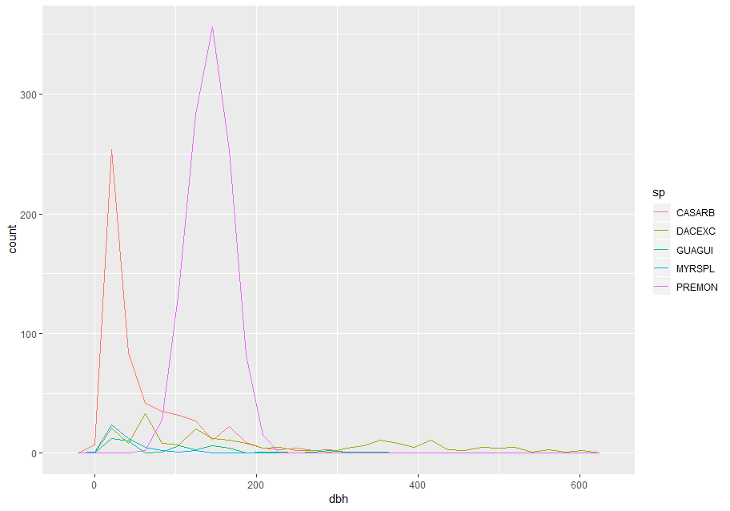

```r
# The dataset has too many species; choosing just a few for clarity
few_sp <- unique(stem$sp)[1:5]
data_few_sp <- filter(stem, sp %in% few_sp)

ggplot(data_few_sp, aes(dbh)) +
  geom_freqpoly(aes(color = sp))
```

It is hard to see the difference in distribution, because the overall counts differ so much:

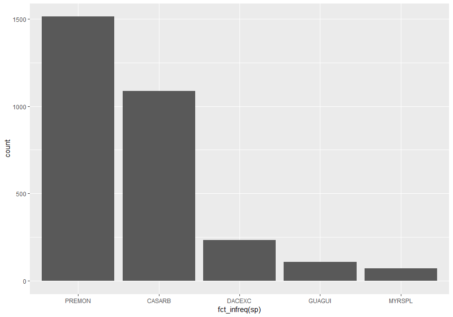

```r
ggplot(data_few_sp) +
  # ordering `sp` from high to low frequency with forcats::fct_infreq()
  geom_bar(mapping = aes(x = fct_infreq(sp)))
```

To make the comparison easier, we need to swap what is displayed on the y-axis. Instead of displaying count, we will display density, which is the count standardized so that the area under each frequency polygon is one.

```
#> Warning: Removed 1008 rows containing non-finite values (stat_bin).
```

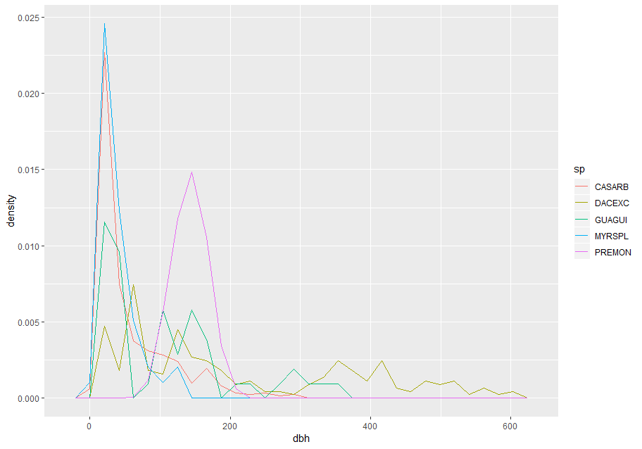

```r
ggplot(data_few_sp, aes(x= dbh, y = ..density..)) +
  geom_freqpoly(aes(color = sp))
```

Another alternative to display the distribution of a continuous variable broken down by a categorical variable is the boxplot. A boxplot is a type of visual shorthand for a distribution of values that is popular among statisticians. Each boxplot consists of:

- A box that stretches from the 25th percentile of the distribution to the 75th percentile, a distance known as the interquartile range (IQR). In the middle of the box is a line that displays the median, i.e. 50th percentile, of the distribution. These three lines give you a sense of the spread of the distribution and whether or not the distribution is symmetric about the median or skewed to one side.
- Visual points that display observations that fall more than 1.5 times the IQR from either edge of the box. These outlying points are unusual so are plotted individually.
- A line (or whisker) that extends from each end of the box and goes to the farthest non-outlier point in the distribution.

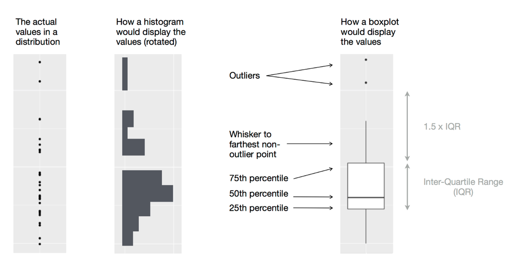

Let’s take a look at the distribution of stem diameter (`dbh`) by species (`sp`) using `geom_boxplot()`:

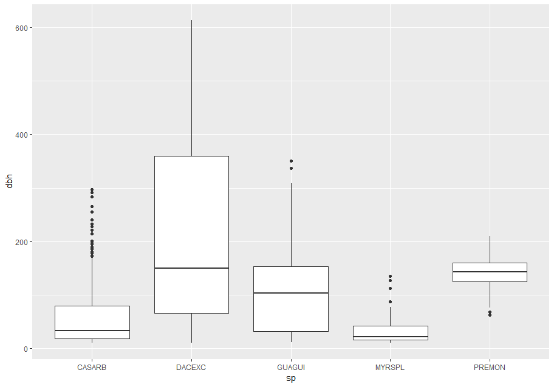

```r
ggplot(data_few_sp, aes(sp, dbh)) +
  geom_boxplot()
```

We see much less information about the distribution, but the boxplots are much more compact so we can more easily compare them (and fit more on one plot).

Above we ordered the variable `sp` by its frequency. Now, to make the trend easier to see, we can reorder `sp` based on the median value of `dbh`. One way to do that is with `reorder()`.

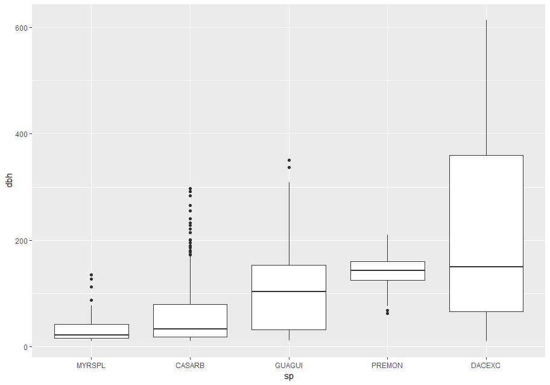

```r
data_few_sp <- data_few_sp %>%
  mutate(sp = reorder(sp, dbh, FUN = median, na.rm = TRUE))

ggplot(data_few_sp, aes(sp, dbh)) +
  geom_boxplot()
```

If you have long variable names, `geom_boxplot()` will work better if you flip it 90°. You can do that with `coord_flip()` (left plot below), or with `ggstance::geom_boxploth()` and swapping `x` and `y` mappings (right plot below):

```r
# Remember to install with install.packages("ggstance")
library(ggstance)
```

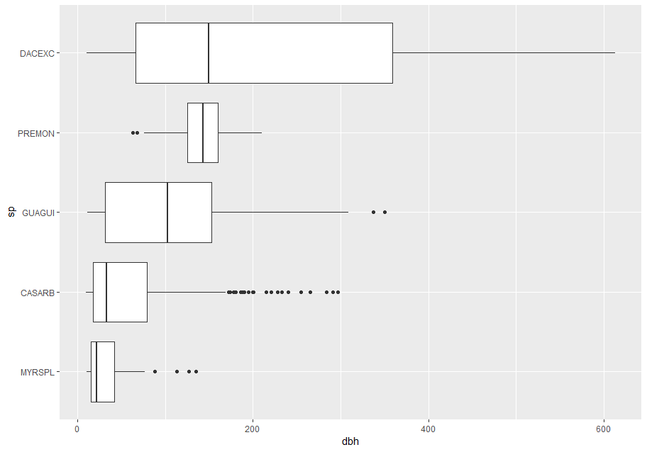

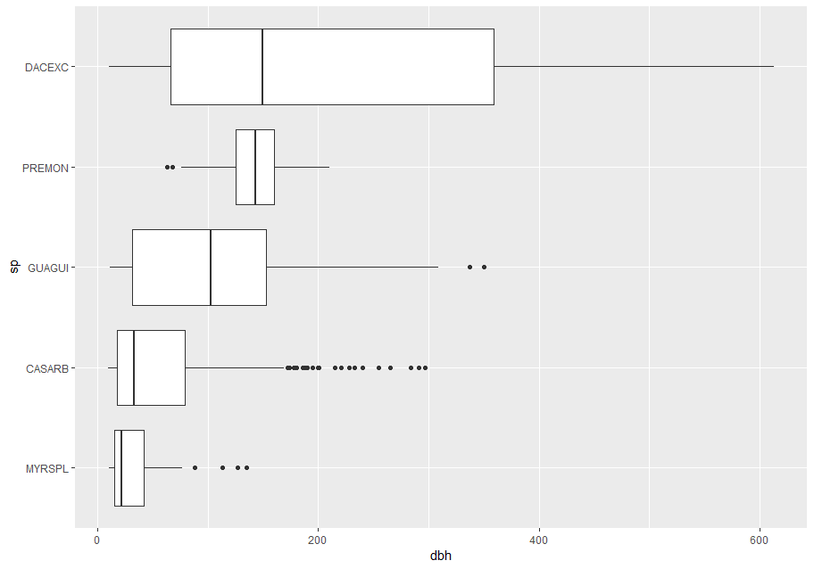

```r
# Left
ggplot2::last_plot() +
  coord_flip()
# Right
ggplot(data_few_sp) +
  ggstance::geom_boxploth(aes(x = dbh, y = sp))  # swap x, y; compare to above
```

### Alternatives

One problem with boxplots is that they were developed in an era of much smaller datasets and tend to display a prohibitively large number of “outlying values”. One approach to remedy this problem is the letter-value plot.

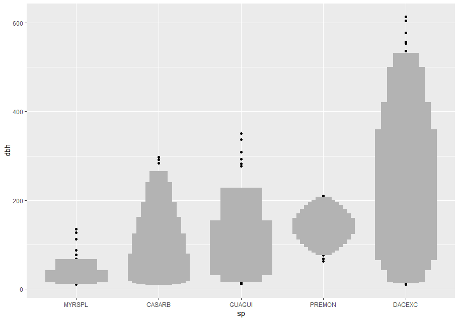

```r
# Remember to install with install.packages("lvplot")
library(lvplot)

ggplot(data_few_sp, aes(sp, dbh)) +
  lvplot::geom_lv()
```

Compare and contrast `geom_violin()` with a faceted `geom_histogram()`, or a colored `geom_freqpoly()` (). What are the pros and cons of each method?

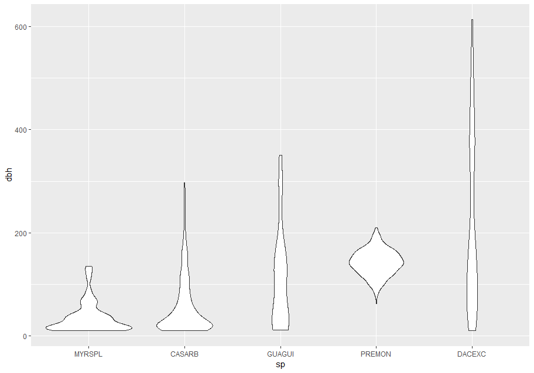

```r
ggplot(data_few_sp, aes(sp, dbh)) +
  geom_violin()
```

```
#> Warning: Removed 1008 rows containing non-finite values (stat_bin).
```

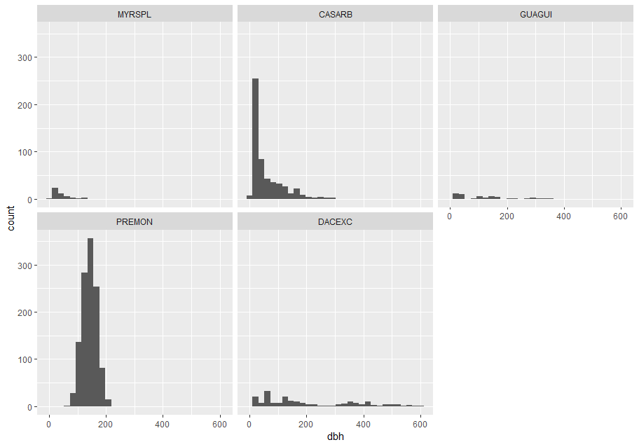

```r
ggplot(data_few_sp, aes(dbh)) +
  geom_histogram() +
  facet_wrap(~sp)
```

If you have a small dataset, it is sometimes useful to use `geom_jitter()` to see the relationship between a continuous and categorical variable. The **ggbeeswarm** package provides a number of methods similar to `geom_jitter()`.

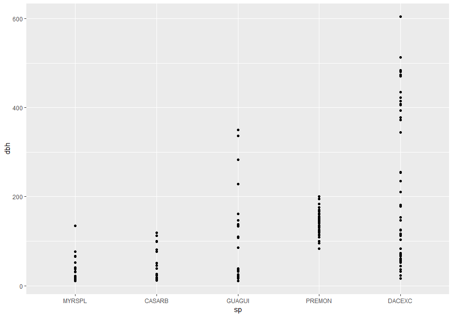

```r
# Remember to install with install.packages("ggbeeswarm")
library(ggbeeswarm)

small_dataset <- data_few_sp %>%
  group_by(sp) %>%
  sample_n(50)

p <- ggplot(small_dataset, aes(sp, dbh))

p + geom_point()
```

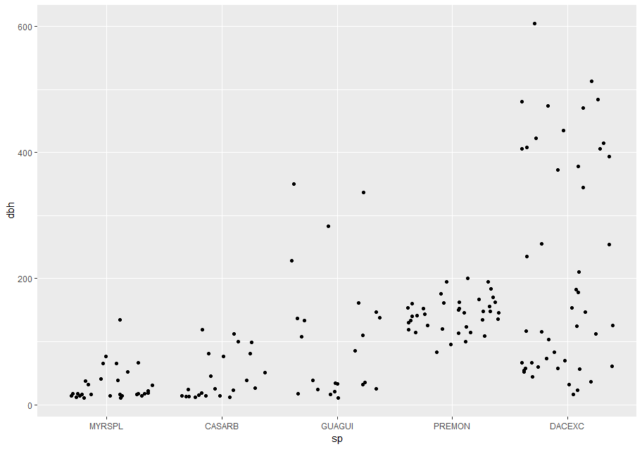

```r
p + geom_jitter()
```

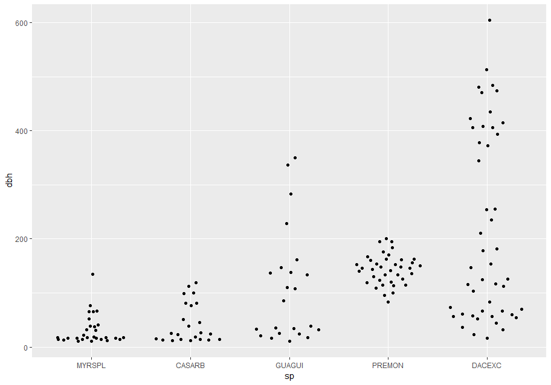

```r
p + ggbeeswarm::geom_quasirandom()
```

## Two categorical variables

To visualize the covariation between categorical variables, you will need to count the number of observations for each combination. One way to do that is to rely on the built-in `geom_count()`. The size of each circle in the plot displays how many observations occurred at each combination of values (left plot below). Covariation will appear as a strong correlation between specific x values and specific y values.

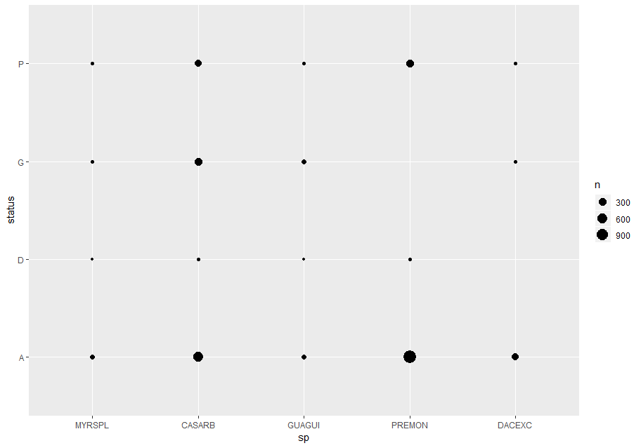

```r
# Simple count
ggplot(data_few_sp) +
  geom_count(aes(x = sp, y = status))
```

To show the distribution of `status` within `sp` (or `sp` within `status`) more clearly, you can map bubble size to a proportion calculated over `sp` (or over `status`):

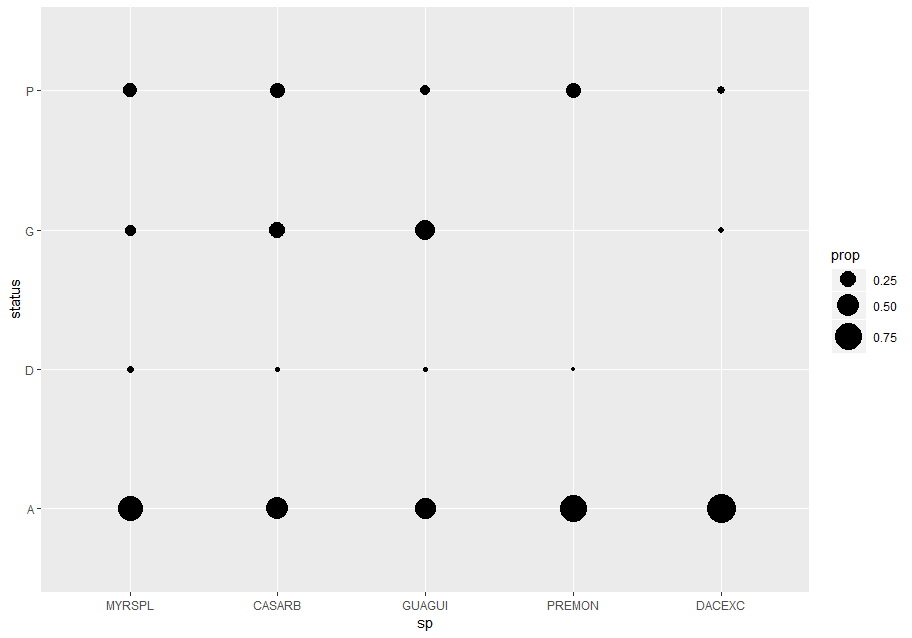

```r
# Proportion; columns sum to 1.
ggplot(data_few_sp, aes(x = sp, y = status)) +
  geom_count(aes(size = ..prop.., group = sp)) +
  scale_size_area(max_size = 10)
```

```r
few_spp_n <- data_few_sp %>%
  count(sp, status)

few_spp_n
```

```
#> # A tibble: 18 x 3
#>    sp     status     n
#>    <fct>  <chr>  <int>
#>  1 MYRSPL A         47
#>  2 MYRSPL D          3
#>  3 MYRSPL G          8
#>  4 MYRSPL P         14
#>  5 CASARB A        541
#>  6 CASARB D         18
#>  7 CASARB G        279
#>  8 CASARB P        248
#>  9 GUAGUI A         50
#> 10 GUAGUI D          2
#> 11 GUAGUI G         46
#> 12 GUAGUI P         10
#> 13 PREMON A       1156
#> 14 PREMON D         18
#> 15 PREMON P        338
#> 16 DACEXC A        213
#> 17 DACEXC G          8
#> 18 DACEXC P         13
```

Then, visualize with `geom_tile()` and the fill aesthetic:

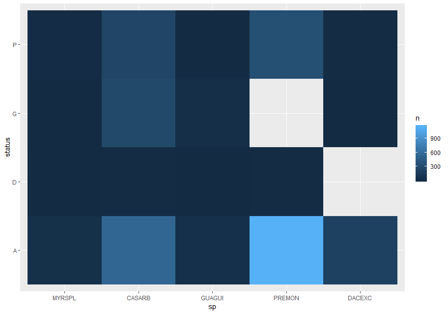

```r
ggplot(few_spp_n, aes(sp, status)) +
  geom_tile(aes(fill = n))
```